# Estudo de Análise de Séries Temporais

# Classes de modelos para séries temporais

Os modelos utilizados para descrever séries temporais são processos estocásticos, isto é, processos controlados por leis probabilísticas.

Algumas das Classes:

- Modelos de Amortecimento Exponencial (têm obtidos bons resultados na graduação)
- Modelos ARIMA (também conta com bons resultados a nível de graduação)
- Modelos GARCH
- Modelos FUZZY
- Modelos de Redes Neurais
- Modelos SSA

Qualquer que seja a classificação do modelo de séries temporais, podemos considerar um número muito grande de modelos diferentes para descrever o comportamento de uma série particular.

## Modelos de Amortecimento Exponencial

A idéia de se usar algum tipo de suavização (ou amortecimento) é que a tendência num instante $t$ será estimada usando-se observações $Z_s$, com $s$ ao redor de $t$, por exemplo, usamos as observações $Z_{t-n},Z_{t-n+1},...,Z_{t+n}$ para estimar $T_t$.

Modelo geral:

$$Z_t=\mu(t)+\epsilon_t$$
onde:

- $\mu(t)$: nível
- $\epsilon_t$: erro (deseja-se $RB(0,\sigma^2_{\epsilon_t}))$

Equação de previsão:

$$\hat Z_t(h)= \hat a_1(t)$$

### NAIVE

Leva em consideração que a previsão de hoje é a mesma de ontem. Porém verificar só a última observação pode nao ser interessante.

No R:

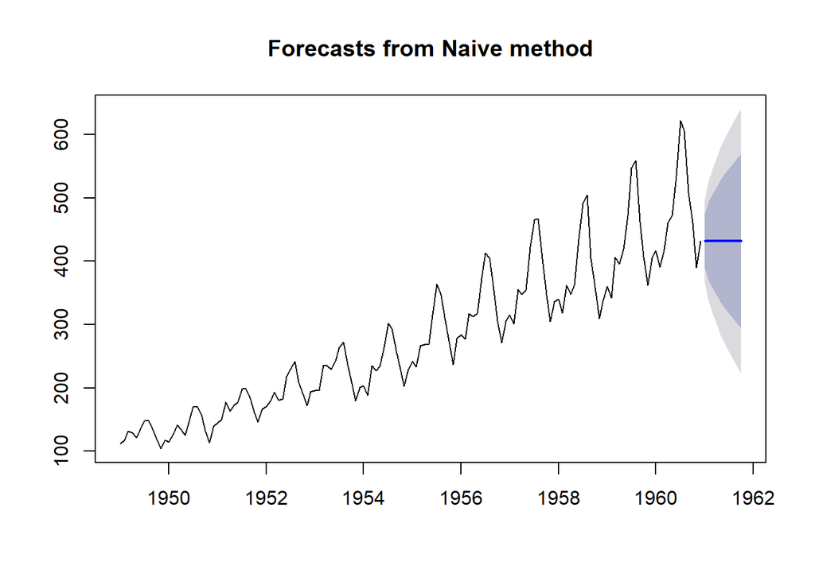

```r
naive=naive(AirPassengers)
plot(naive)
```

Levando a sazonalidade em consideração:

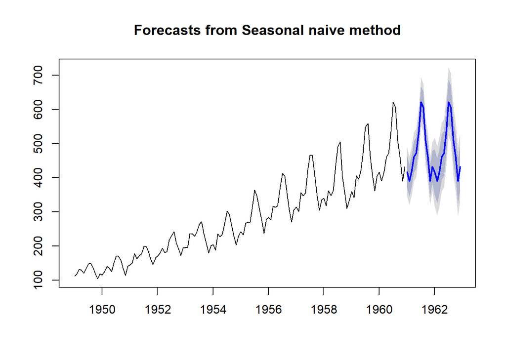

```r
snaive=snaive(AirPassengers)
plot(snaive)
```

### Médias móveis MM(N)

O estimador de $a_1$ é a média das últimas $N$ observações.

Note que se utilizamos $N=1$ voltamos ao método NAIVE e se utilizamos $N=T$ utilizando todas as observações, é tido como um método conservador.

No R:

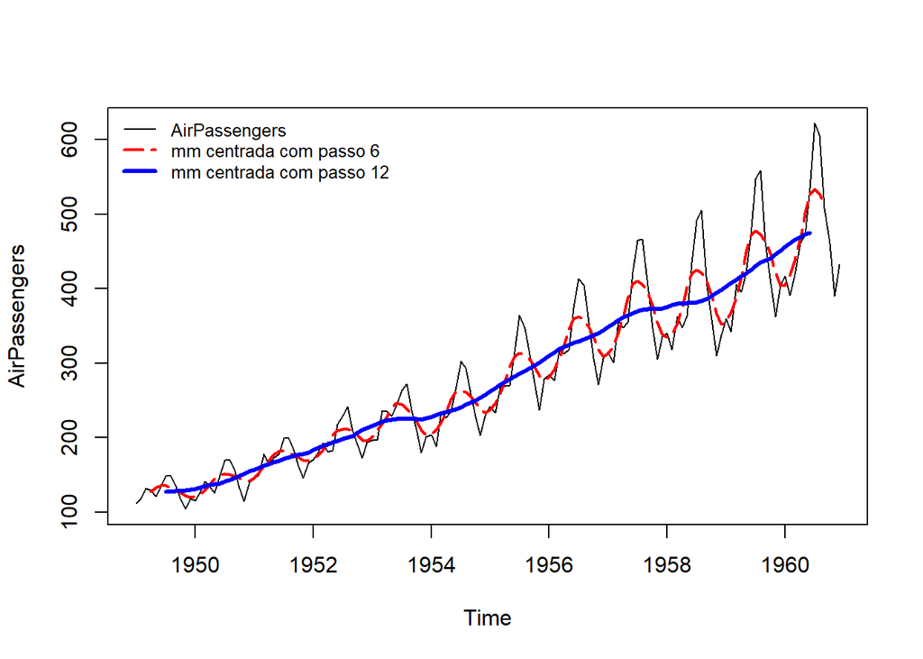

```r
#Ajustando o modelo:
mm_centrada_ordem6<- ma(AirPassengers,order=6)
mm_centrada_ordem12<- ma(AirPassengers,order=12)
#Nota:  order é tamanho da janela (argumento obrigatório)

#Plot do modelo:
plot(AirPassengers)
lines(mm_centrada_ordem6,col="red",lty=5,lwd =2)
lines(mm_centrada_ordem12,col="blue",lty=1,lwd =3)
legend('topleft', legend=c("AirPassengers", "mm centrada com passo 6", "mm centrada com passo 12"),
bty = "n",col=c("black","red", "blue"), lty=c(1,5,1), cex=0.8,
lwd =c(1,2,3))
```

A escolha de $N$ deve ser feita tal que a $SQE$ seja minimizada, onde:

- $SQE$: Soma dos Quadrados dos erros de previsão

que é uma das ferramentas para minimizar os erros e encontrar o menor valor de $N$.

### Amortecimento Exponencial simples

Este método dá pesos maiores às observações mais recentes captando melhor as mudanças de comportamento. A previsão desse modelo é igual ao último valor exponencial suavizado obtido.

Assumindo $\alpha$ como contante de amortecimento, $\alpha=\frac{1}{N};\alpha \in (0,1)$, dessa forma:

$$M_T=\alpha Z_T + (1-\alpha)M_{T-1}$$

onde:

- $Z_t$ é o valor observado da série temporal $Z$ no tempo $t$;
- $\hat Z_t$ é o valor exponencialmente suavizado no tempo $t$;
- $\alpha$ é a constante de suavização.

No R o ajuste pode ser feito da seguinte maneira:

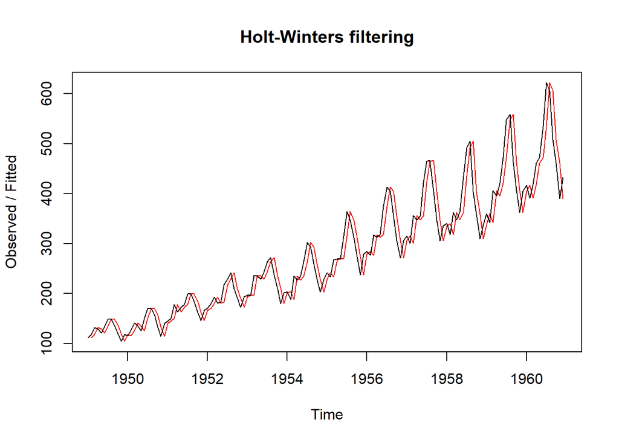

```r
amortecimento_exponencial_simples<-HoltWinters(AirPassengers, beta=FALSE, gamma=FALSE)
plot(amortecimento_exponencial_simples)
```

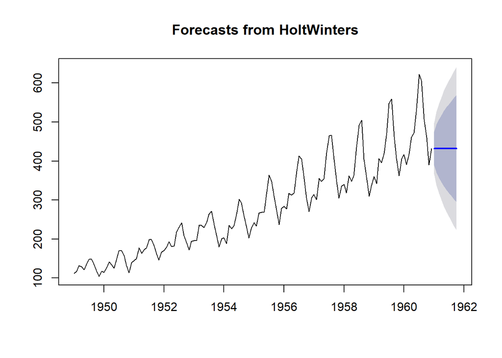

```r
previsao<-forecast(amortecimento_exponencial_simples,h=10)
plot(previsao)
```

### “Lowess”

A sigla “lowess” significa “locally weighted regression scatter plot smoothing”. Isto significa que a suavização é feita através de sucessivos ajustes de retas de mínimos quadrados ponderados a sub-conjuntos de dados

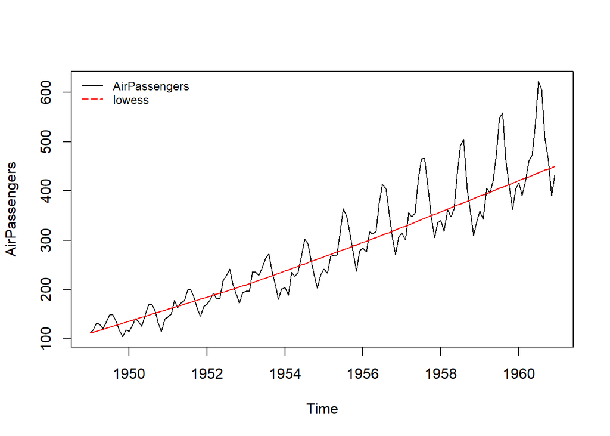

```r
lowess=lowess(AirPassengers)
plot(AirPassengers)
lines(lowess, col="red")
legend('topleft', legend=c("AirPassengers", "lowess"),
bty = "n",col=c("black","red"), lty=c(1,5,1), cex=0.8)
```

## Método de Amortecimento exponencial de Holt (dados com tendência)

O método de amortecimento exponencial simples quando aplicado a uma série que apresenta tendência linear positiva (ou negativa) fornece previsões que subestimam (ou superestimam) continuamente os valores reais.

Para evitar esse erro sistemático, um dos métodos é aplicar o amortecimento exponencial de Holt. Esse método é similar, em princípio, ao amortecimento exponencial simples, a diferença é que em vez de suavizar só o nível, ele utiliza uma nova constante de suavização para “modelar” a tendência da série.

O modelo de tendência linear:

$$Z_T=a_1 + a_2 t + \epsilon_t$$
no qual $\epsilon_t \sim RB(0,\sigma^2_{\epsilon_t})$ , $a_1$: nível e $a_2$: tendência

e a equação de atualização do parâmetro é dada da seguinte forma:

$$\hat a_1(t)= \alpha Z_t + (1- \alpha) [\hat a_1(t-1)=\hat a_2(t-1) ] \\
\hat a_2(t)= \beta [ \hat a_1(t)-\hat a_1(t-1)]+(1-\beta) \hat a_2 (t-1)$$

onde:

- $\alpha$: constante de amortecimento do nível e $0< \alpha <1$
- $beta$: constante de amortecimento da tendência e $0< \beta <1$

No R:

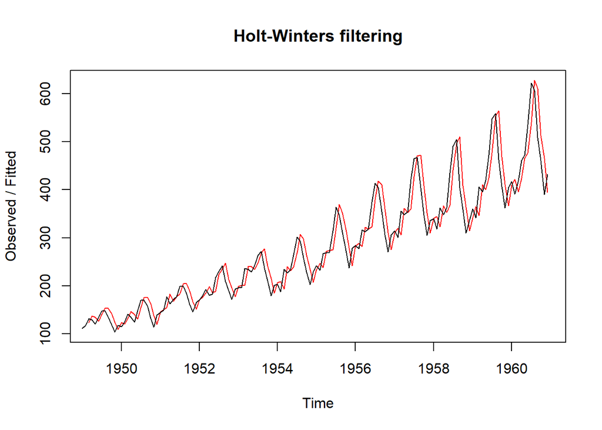

```r
ajuste_com_tendencia<-HoltWinters(AirPassengers, gamma=FALSE)
plot(ajuste_com_tendencia)
```

### Damped Trend

É a tendência “amortecida”, “regulada”, pode ser obtido com a inclusão de um hieprparâmetro $0<\phi<1$, veja:

$$Z_T=a_1 + a_2 t + \big[\sum^h_{i=1} \phi^i \big]$$
Portanto, aqui teremos o uso de 3 hiperparâmetros e 2 parâmetros

No R:

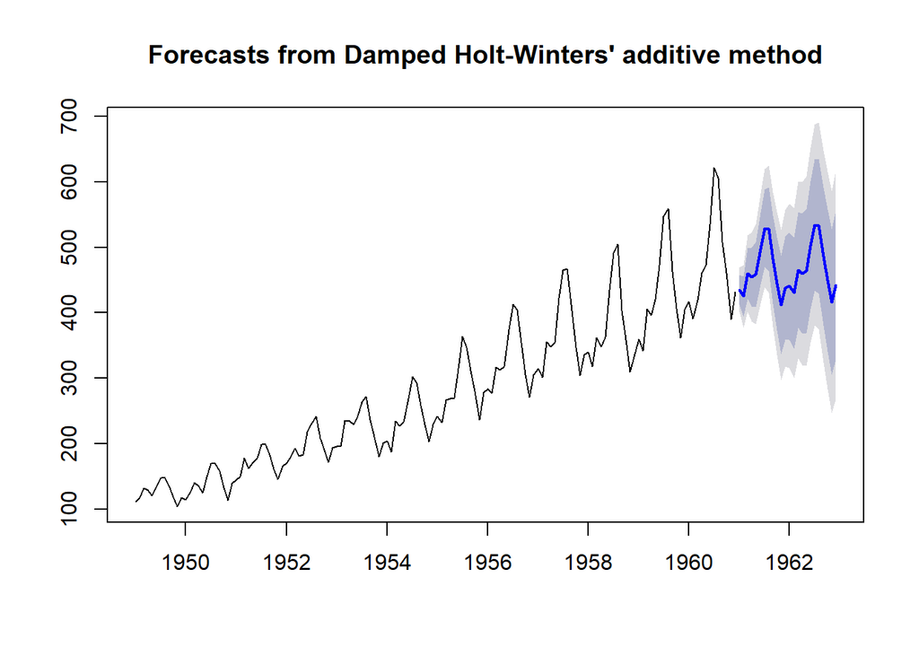

```r
ajuste_com_damped<-hw(AirPassengers,gamma=NULL,damped = T)
plot(ajuste_com_damped)
```

# Modelagem In-Sample e Out-Sample

Como comparamos os ajustes para saber se a previsão foi boa?

Podemos separar uma parte da amostra para treino (dentro da amostra) e outra parte da amostra para teste (fora da amostra), com isso teremos a série observada e a série ajustada.

O modelo aprende a acompanhar o comportamento da série e depois deixa executar sozinho.

# Estatísticas de Aderência

Avalia o poder preditivo ou a acurácia do modelo, temos as seguintes estatísticas:

- MAD (Mean Absolute Desviation)(desvio médio absoluto)
- MAE (Mean Absolute Erro)(erro médio absoluto)
- MSE (Mean Square Error)(erro quadrático médio)
- RMSE(Root Mean Square Error)(raiz quadrada do erro quadrático médio)
- MAPE (Mean Absolute Percentege Error)(Erro médio percentual absoluto)

Sabemos que:

- $Z_t$: é dado observado no tempo $t$
- $\hat Z_t$ é dado ajustado pelo modelo no tempo $t$

Portanto $Z_t-\hat Z_t$ é o erro de previsão.

Estamos interessados em encontrar o menor de todos. Quanto menor, melhor!

# Sazonalidade

Padrões típidos no comportamento da série que se repetem periodicamente.

Notação:

- $\rho_t$: fator sazonal

Então, temos $\rho_1,...,\rho_s$, $s$=nº de fatores sazonais.

Uma propriedade importante:

- $\sum^s_{i=1}=s$

## Método de Amortecimento exponencial de Holt-Winters (dados com sazonalidade)

Este modelo ajuda a descobrir padrão de comportamento mais complexos. A previsao deste modelo é feita de acordo com a série que pode ser Sazonal Aditiva ou Sazonal Multiplicativa.

É uma adaptação do modelo de amortecimento exponencial de Holt-Winters para dados com sazonalidade. o parâmtro $\rho$ será incluído nas equações e teremos um novo parâmtro que será a constante de amortecimento dos fatores sazonais, dada por:

- $\gamma$: constante de amortecimento dos fatores sazonais

Além do parâmetro a ser estimado:

- $\hat \rho_{m(t)} (t)$: estimador dos fatores sazonais em $t$ ($s$ fatores sazonais)

No R, considerando a série sazonal aditiva (por default do R):

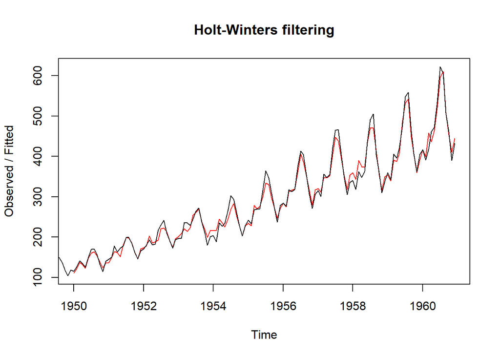

```r
ajuste_com_sazonalidade<-HoltWinters(AirPassengers)
plot(ajuste_com_sazonalidade)
```

Com a função `forecast()` podemos obter previsoes do modelo, veja:

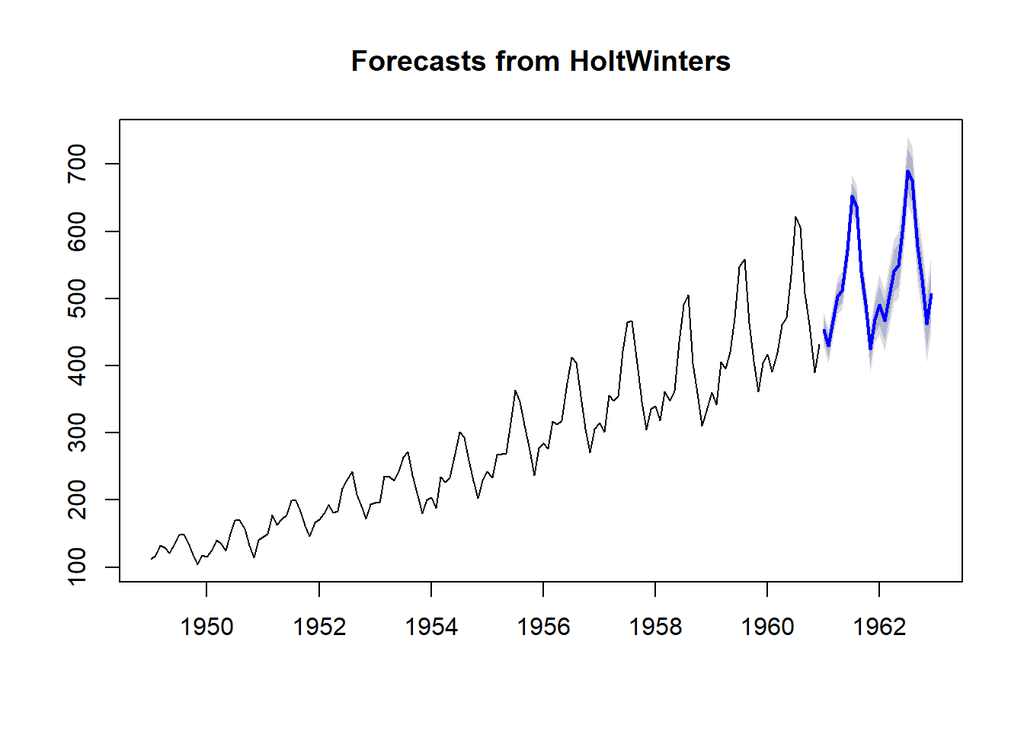

```r
previsao_com_sazonalidade<-forecast(ajuste_com_sazonalidade)
plot(previsao_com_sazonalidade)
```

# Modelos ARIMA

Box & jankis propuseram esta classe de modelagem autoregressiva integrada e de médias móveis. Os objetivos principais desse tipo de ajuste são:

- Especificar a classe geral do modelo
- identificar o modelo a partir das funções de autocorrelação e autocorrelação parcial
- Estimação dos parâmetros do modelo
- Diagnóstico do modelo

Considere que o deslocamento de “$k$” unidades de tempo será usado com a notação **lag**.

**Def.:** (Autocovariância de lag $k$)

- $\gamma_k$= $cov(Z_t, Z_{t+k})$ = $cov(Z_t, Z_{t-k})$ = $\gamma_{-k}$
- Se $k=0$ , então $\gamma_0$= $cov(Z_t, Z_{t})$ = $var(Z_t)$

**Def.:** (Função de Autocorrelação)(FAC) (ACF em inglês)

- $\rho=\frac{\gamma_k}{\gamma_0}$
- Correlogramas mostram o comportamento da FAC

No R:

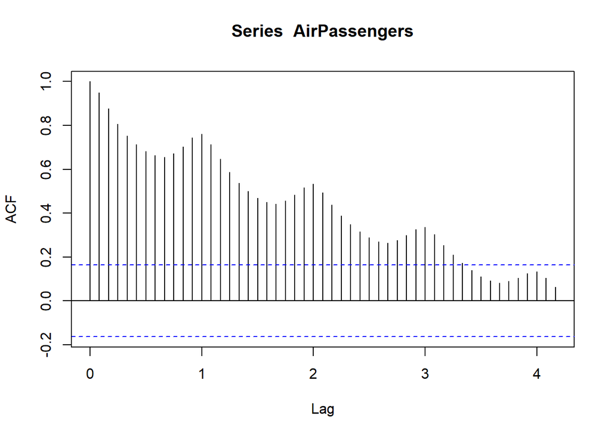

```r
acf(AirPassengers, lag.max = 50)
```

**Def.:** (Função de Autocorrelação parcial)(FACP) (PACF em inglês) É a correlação entre $Z_t$ e $Z_{t+k}$ retirndo o efeito dos valores intermediários

No R:

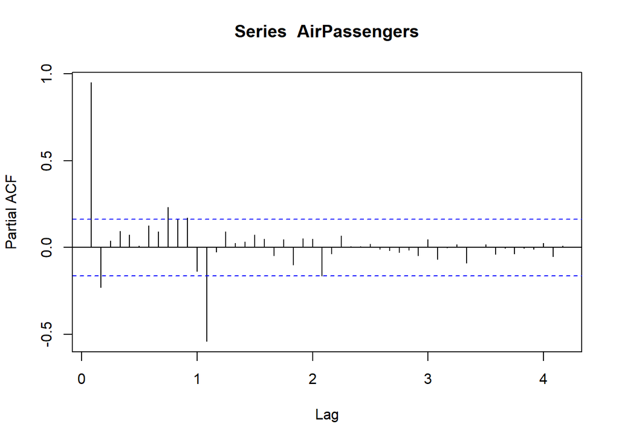

```r
pacf(AirPassengers, lag.max = 50)
```

### Generalizando

| Modelo | FAC | FACP |
| --- | --- | --- |
| AR(p) | decrescimento exponencial | corte brusco até o lag $p$ |
| MA(q) | cortes bruscos até o lag $q$ | decrescimento exponencial |
| ARMA(p,q) | Decresce exponencialmente com cortes bruscos até o lag $q$ | Decresce exponencialmente com cortes bruscos até o lag $p$ |

### Processo de Box-Jenkis

O processo de Box-Jenkis é dado por:

- $Z_t=\psi(B)\epsilon_t$
- $Z_t=\frac{\theta(B)}{\phi(B)}\epsilon_t$

Portando o processo linear geral é dado por:

$$\phi(B)Z_t=\theta(B)\epsilon_t$$